# Homework 5

Chen Yi-Ju(Ernie)

2020/6/17

## Question 11.1

### Using the crime data set uscrime.txt from Questions 8.2, 9.1, and 10.1, build a regression model using:

### 1. Stepwise regression

### 2. Lasso

### 3. Elastic net

```r
setwd("D:/ernie/self-study/GTxMicroMasters/Introduction to Analytics Modeling/week5/homework")
#loading library
library(tidyverse)
library(caret)
library(egg)
library(stargazer)
library(modelr)
library(glmnet)
library(foreach)
library(FrF2)
```

```r
#loading data
crime <- read.table("uscrime.txt" , header = T)
```

### 1. Stepwise regression

```r
#dividing into training and testing data sets
set.seed(101)
train.index <- createDataPartition(crime$Crime , p = 0.8 ,times = 1, list = F)
train <- crime[train.index,]
test <- crime[-train.index,]
```

First, I try using forward stepwise regression

```r
#Forward stepwise
null = lm (Crime ~1, data = train) #setting upper bound
full = lm(Crime ~., data = train) #setting lower bound
```

Using the step function

```r
#step function

forward.sel <- step(null,
                    scope = list(lower = null , upper = full),
                    direction = "forward")
```

```
## Start:  AIC=468.47
## Crime ~ 1
##
##          Df Sum of Sq     RSS    AIC
## + Po1     1   2797294 3305694 446.56
## + Po2     1   2660798 3442189 448.13
## + Wealth  1   1343570 4759417 460.77
## + Prob    1   1342223 4760764 460.78
## + Pop     1    658975 5444012 466.01
## + Ed      1    641565 5461423 466.14
## + U2      1    472098 5630890 467.33
## + Time    1    359554 5743434 468.10
## <none>                6102988 468.47
## + Ineq    1    281710 5821277 468.63
## + M.F     1    275417 5827570 468.67
## + LF      1    105190 5997798 469.79
## + M       1     70170 6032817 470.02
## + So      1     23568 6079420 470.32
## + NW      1       815 6102172 470.46
## + U1      1       258 6102730 470.47
##
## Step:  AIC=446.56
## Crime ~ Po1
##
##          Df Sum of Sq     RSS    AIC
## + M       1    571704 2733990 441.15
## + Ineq    1    542382 2763312 441.57
## + M.F     1    261831 3043862 445.34
## + So      1    209343 3096350 446.00
## + NW      1    183579 3122115 446.33
## <none>                3305694 446.56
## + Prob    1    140296 3165398 446.86
## + Wealth  1     96884 3208810 447.40
## + Time    1     91357 3214337 447.46
## + Po2     1     87071 3218622 447.52
## + LF      1     55811 3249882 447.89
## + U2      1     17648 3288046 448.35
## + Pop     1     14427 3291267 448.39
## + Ed      1      4680 3301014 448.50
## + U1      1       673 3305021 448.55
```

[output cut: 97 more lines]

```
## + LF      1      1075 1404911 427.18
## + NW      1        71 1405915 427.21
##
## Step:  AIC=422.5
## Crime ~ Po1 + M + M.F + Ineq + Ed + U2 + Prob + U1
##
##          Df Sum of Sq     RSS    AIC
## <none>                1245895 422.50
## + So      1     47478 1198417 422.99
## + Wealth  1     31144 1214750 423.51
## + LF      1     25300 1220595 423.70
## + Po2     1     17337 1228558 423.95
## + Pop     1      4512 1241383 424.36
## + NW      1      4157 1241738 424.37
## + Time    1         0 1245895 424.50
```

We can see from the progress that AIC is decreasing.

```r
summary(forward.sel)
```

```
##
## Call:
## lm.default(formula = Crime ~ Po1 + M + M.F + Ineq + Ed + U2 +
##     Prob + U1, data = train)
##
## Residuals:
##     Min      1Q  Median      3Q     Max
## -397.75 -106.78   14.48  141.65  507.68
##
## Coefficients:
##             Estimate Std. Error t value Pr(>|t|)
## (Intercept) -7306.48    1380.30  -5.293 1.02e-05 ***
## Po1            94.95      18.67   5.085 1.83e-05 ***
## M             100.62      37.41   2.690 0.011570 *
## M.F            29.67      15.61   1.901 0.066909 .
## Ineq           59.89      16.42   3.647 0.000998 ***
## Ed            185.06      57.91   3.195 0.003277 **
## U2            267.71      94.08   2.845 0.007919 **
## Prob        -3238.63    1642.54  -1.972 0.057924 .
## U1          -8256.55    4205.28  -1.963 0.058931 .
## ---
## Signif. codes:  0 '***' 0.001 '**' 0.01 '*' 0.05 '.' 0.1 ' ' 1
##
## Residual standard error: 203.8 on 30 degrees of freedom
## Multiple R-squared:  0.7959, Adjusted R-squared:  0.7414
## F-statistic: 14.62 on 8 and 30 DF,  p-value: 1.924e-08
```

Testing model on test data

```r
#Testing
res.forw <- test %>%
  add_predictions(.,forward.sel) %>%
  select('observations' = Crime, pred) %>%
  as.data.frame()
```

Summary of the results:

```r
forward <- postResample(obs = res.forw$observations, pred = res.forw$pred)
forward
```

```
##        RMSE    Rsquared         MAE
## 192.5011883   0.6075089 164.3968602
```

```r
#Backwards stepwise
backward.sel<- step( full,
  scope = list(upper = full , lower = null),
  direction = "backward")
```

```
## Start:  AIC=431.79
## Crime ~ M + So + Ed + Po1 + Po2 + LF + M.F + Pop + NW + U1 +
##     U2 + Wealth + Ineq + Prob + Time
##
##          Df Sum of Sq     RSS    AIC
## - LF      1      2779 1106877 429.89
## - Time    1      2840 1106938 429.89
## - Pop     1     11369 1115467 430.19
## - NW      1     19010 1123108 430.45
## - Po2     1     23858 1127957 430.62
## - Wealth  1     31358 1135456 430.88
## - M.F     1     36810 1140908 431.07
## - So      1     40666 1144764 431.20
## - U1      1     49580 1153678 431.50
## <none>                1104098 431.79
## - Prob    1     86348 1190446 432.72
## - Po1     1    104236 1208334 433.31
## - U2      1    208412 1312510 436.53
## - M       1    221814 1325912 436.93
## - Ineq    1    276544 1380642 438.51
## - Ed      1    356788 1460886 440.71
##
## Step:  AIC=429.89
## Crime ~ M + So + Ed + Po1 + Po2 + M.F + Pop + NW + U1 + U2 +
##     Wealth + Ineq + Prob + Time
##
##          Df Sum of Sq     RSS    AIC
## - Time    1      3685 1110562 428.02
## - Pop     1     13888 1120765 428.37
## - Po2     1     21642 1128519 428.64
## - NW      1     26993 1133870 428.83
## - Wealth  1     30524 1137401 428.95
## - M.F     1     36283 1143160 429.14
## - U1      1     48877 1155754 429.57
## <none>                1106877 429.89
## - So      1     66054 1172932 430.15
## - Prob    1     83908 1190785 430.74
## - Po1     1    101689 1208566 431.31
## - U2      1    205953 1312830 434.54
## - M       1    234351 1341228 435.38
```

[output cut: 89 more lines]

```
## - Po1   1    974280 2172697 444.19
##
## Step:  AIC=422.5
## Crime ~ M + Ed + Po1 + M.F + U1 + U2 + Ineq + Prob
##
##        Df Sum of Sq     RSS    AIC
## <none>              1245895 422.50
## - M.F   1    150124 1396019 424.94
## - U1    1    160091 1405986 425.21
## - Prob  1    161456 1407350 425.25
## - M     1    300427 1546322 428.93
## - U2    1    336243 1582138 429.82
## - Ed    1    424053 1669948 431.92
## - Ineq  1    552239 1798133 434.81
## - Po1   1   1073853 2319748 444.74
```

```r
summary(backward.sel)
```

```
##
## Call:
## lm.default(formula = Crime ~ M + Ed + Po1 + M.F + U1 + U2 + Ineq +
##     Prob, data = train)
##
## Residuals:
##     Min      1Q  Median      3Q     Max
## -397.75 -106.78   14.48  141.65  507.68
##
## Coefficients:
##             Estimate Std. Error t value Pr(>|t|)
## (Intercept) -7306.48    1380.30  -5.293 1.02e-05 ***
## M             100.62      37.41   2.690 0.011570 *
## Ed            185.06      57.91   3.195 0.003277 **
## Po1            94.95      18.67   5.085 1.83e-05 ***
## M.F            29.67      15.61   1.901 0.066909 .
## U1          -8256.55    4205.28  -1.963 0.058931 .
## U2            267.71      94.08   2.845 0.007919 **
## Ineq           59.89      16.42   3.647 0.000998 ***
## Prob        -3238.63    1642.54  -1.972 0.057924 .
## ---
## Signif. codes:  0 '***' 0.001 '**' 0.01 '*' 0.05 '.' 0.1 ' ' 1
##
## Residual standard error: 203.8 on 30 degrees of freedom
## Multiple R-squared:  0.7959, Adjusted R-squared:  0.7414
## F-statistic: 14.62 on 8 and 30 DF,  p-value: 1.924e-08
```

```r
#Testing
res.back <- test %>%
  add_predictions(.,backward.sel) %>%
  select('observations' = Crime, pred) %>%
  as.data.frame()
backward <- postResample(obs = res.back$observations, pred = res.back$pred)
backward
```

```
##        RMSE    Rsquared         MAE
## 192.5011883   0.6075089 164.3968602
```

Finally, we do stepwise regression from both sides, starting from no parameters (null) and all parameters(full)

```r
# Stepwise regression
step.both.1 <- step(null, scope = list(upper = full) , direction = "both")
```

```
## Start:  AIC=468.47
## Crime ~ 1
##
##          Df Sum of Sq     RSS    AIC
## + Po1     1   2797294 3305694 446.56
## + Po2     1   2660798 3442189 448.13
## + Wealth  1   1343570 4759417 460.77
## + Prob    1   1342223 4760764 460.78
## + Pop     1    658975 5444012 466.01
## + Ed      1    641565 5461423 466.14
## + U2      1    472098 5630890 467.33
## + Time    1    359554 5743434 468.10
## <none>                6102988 468.47
## + Ineq    1    281710 5821277 468.63
## + M.F     1    275417 5827570 468.67
## + LF      1    105190 5997798 469.79
## + M       1     70170 6032817 470.02
## + So      1     23568 6079420 470.32
## + NW      1       815 6102172 470.46
## + U1      1       258 6102730 470.47
##
## Step:  AIC=446.56
## Crime ~ Po1
##
##          Df Sum of Sq     RSS    AIC
## + M       1    571704 2733990 441.15
## + Ineq    1    542382 2763312 441.57
## + M.F     1    261831 3043862 445.34
## + So      1    209343 3096350 446.00
## + NW      1    183579 3122115 446.33
## <none>                3305694 446.56
## + Prob    1    140296 3165398 446.86
## + Wealth  1     96884 3208810 447.40
## + Time    1     91357 3214337 447.46
## + Po2     1     87071 3218622 447.52
## + LF      1     55811 3249882 447.89
## + U2      1     17648 3288046 448.35
## + Pop     1     14427 3291267 448.39
## + Ed      1      4680 3301014 448.50
## + U1      1       673 3305021 448.55
```

[output cut: 133 more lines]

```
## + So      1     47478 1198417 422.99
## + Wealth  1     31144 1214750 423.51
## + LF      1     25300 1220595 423.70
## + Po2     1     17337 1228558 423.95
## + Pop     1      4512 1241383 424.36
## + NW      1      4157 1241738 424.37
## + Time    1         0 1245895 424.50
## - M.F     1    150124 1396019 424.94
## - U1      1    160091 1405986 425.21
## - Prob    1    161456 1407350 425.25
## - M       1    300427 1546322 428.93
## - U2      1    336243 1582138 429.82
## - Ed      1    424053 1669948 431.92
## - Ineq    1    552239 1798133 434.81
## - Po1     1   1073853 2319748 444.74
```

```r
step.both.2 <- step(full, scope = list(upper = full), direction = "both")
```

```
## Start:  AIC=431.79
## Crime ~ M + So + Ed + Po1 + Po2 + LF + M.F + Pop + NW + U1 +
##     U2 + Wealth + Ineq + Prob + Time
##
##          Df Sum of Sq     RSS    AIC
## - LF      1      2779 1106877 429.89
## - Time    1      2840 1106938 429.89
## - Pop     1     11369 1115467 430.19
## - NW      1     19010 1123108 430.45
## - Po2     1     23858 1127957 430.62
## - Wealth  1     31358 1135456 430.88
## - M.F     1     36810 1140908 431.07
## - So      1     40666 1144764 431.20
## - U1      1     49580 1153678 431.50
## <none>                1104098 431.79
## - Prob    1     86348 1190446 432.72
## - Po1     1    104236 1208334 433.31
## - U2      1    208412 1312510 436.53
## - M       1    221814 1325912 436.93
## - Ineq    1    276544 1380642 438.51
## - Ed      1    356788 1460886 440.71
##
## Step:  AIC=429.89
## Crime ~ M + So + Ed + Po1 + Po2 + M.F + Pop + NW + U1 + U2 +
##     Wealth + Ineq + Prob + Time
##
##          Df Sum of Sq     RSS    AIC
## - Time    1      3685 1110562 428.02
## - Pop     1     13888 1120765 428.37
## - Po2     1     21642 1128519 428.64
## - NW      1     26993 1133870 428.83
## - Wealth  1     30524 1137401 428.95
## - M.F     1     36283 1143160 429.14
## - U1      1     48877 1155754 429.57
## <none>                1106877 429.89
## - So      1     66054 1172932 430.15
## - Prob    1     83908 1190785 430.74
## - Po1     1    101689 1208566 431.31
## + LF      1      2779 1104098 431.79
## - U2      1    205953 1312830 434.54
```

[output cut: 117 more lines]

```
## + So      1     47478 1198417 422.99
## + Wealth  1     31144 1214750 423.51
## + LF      1     25300 1220595 423.70
## + Po2     1     17337 1228558 423.95
## + Pop     1      4512 1241383 424.36
## + NW      1      4157 1241738 424.37
## + Time    1         0 1245895 424.50
## - M.F     1    150124 1396019 424.94
## - U1      1    160091 1405986 425.21
## - Prob    1    161456 1407350 425.25
## - M       1    300427 1546322 428.93
## - U2      1    336243 1582138 429.82
## - Ed      1    424053 1669948 431.92
## - Ineq    1    552239 1798133 434.81
## - Po1     1   1073853 2319748 444.74
```

```r
summary(step.both.1)
```

```
##
## Call:
## lm.default(formula = Crime ~ Po1 + M + M.F + Ineq + Ed + U2 +
##     Prob + U1, data = train)
##
## Residuals:
##     Min      1Q  Median      3Q     Max
## -397.75 -106.78   14.48  141.65  507.68
##
## Coefficients:
##             Estimate Std. Error t value Pr(>|t|)
## (Intercept) -7306.48    1380.30  -5.293 1.02e-05 ***
## Po1            94.95      18.67   5.085 1.83e-05 ***
## M             100.62      37.41   2.690 0.011570 *
## M.F            29.67      15.61   1.901 0.066909 .
## Ineq           59.89      16.42   3.647 0.000998 ***
## Ed            185.06      57.91   3.195 0.003277 **
## U2            267.71      94.08   2.845 0.007919 **
## Prob        -3238.63    1642.54  -1.972 0.057924 .
## U1          -8256.55    4205.28  -1.963 0.058931 .
## ---
## Signif. codes:  0 '***' 0.001 '**' 0.01 '*' 0.05 '.' 0.1 ' ' 1
##
## Residual standard error: 203.8 on 30 degrees of freedom
## Multiple R-squared:  0.7959, Adjusted R-squared:  0.7414
## F-statistic: 14.62 on 8 and 30 DF,  p-value: 1.924e-08
```

```r
summary(step.both.2)
```

```
##
## Call:
## lm.default(formula = Crime ~ M + Ed + Po1 + M.F + U1 + U2 + Ineq +
##     Prob, data = train)
##
## Residuals:
##     Min      1Q  Median      3Q     Max
## -397.75 -106.78   14.48  141.65  507.68
##
## Coefficients:
##             Estimate Std. Error t value Pr(>|t|)
## (Intercept) -7306.48    1380.30  -5.293 1.02e-05 ***
## M             100.62      37.41   2.690 0.011570 *
## Ed            185.06      57.91   3.195 0.003277 **
## Po1            94.95      18.67   5.085 1.83e-05 ***
## M.F            29.67      15.61   1.901 0.066909 .
## U1          -8256.55    4205.28  -1.963 0.058931 .
## U2            267.71      94.08   2.845 0.007919 **
## Ineq           59.89      16.42   3.647 0.000998 ***
## Prob        -3238.63    1642.54  -1.972 0.057924 .
## ---
## Signif. codes:  0 '***' 0.001 '**' 0.01 '*' 0.05 '.' 0.1 ' ' 1
##
## Residual standard error: 203.8 on 30 degrees of freedom
## Multiple R-squared:  0.7959, Adjusted R-squared:  0.7414
## F-statistic: 14.62 on 8 and 30 DF,  p-value: 1.924e-08
```

```r
#Testing
res.both.1 <- test %>%
  add_predictions(.,step.both.1) %>%
  select('observations' = Crime, pred) %>%
  as.data.frame()
res.both.2 <- test %>%
  add_predictions(.,step.both.2) %>%
  select('observations' = Crime, pred) %>%
  as.data.frame()
```

```r
#Prediction
stepwise.fromNull <- postResample(obs = res.both.1$observations, pred = res.both.1$pred)
stepwise.fromFull <- postResample(obs = res.both.2$observations, pred = res.both.2$pred)
```

```r
stepwise.fromNull
```

```
##        RMSE    Rsquared         MAE
## 192.5011883   0.6075089 164.3968602
```

```r
stepwise.fromFull
```

```
##        RMSE    Rsquared         MAE
## 192.5011883   0.6075089 164.3968602
```

Below is the results on test data of all 4 methods:

```r
data.frame(forward,backward,stepwise.fromFull,stepwise.fromNull)
```

```
##              forward    backward stepwise.fromFull stepwise.fromNull
## RMSE     192.5011883 192.5011883       192.5011883       192.5011883
## Rsquared   0.6075089   0.6075089         0.6075089         0.6075089
## MAE      164.3968602 164.3968602       164.3968602       164.3968602
```

### 2. Lasso

Then we try the Lasso method:  
Slitting data

```r
set.seed(101)
train.index <- createDataPartition(crime$Crime , p = 0.8 ,times = 1, list = F)
train <- crime[train.index,]
test <- crime[-train.index,]
```

Building model

```r
#modeling
lasso <- glmnet(x = scale(as.matrix(train[,-16])),
                y =scale(as.matrix(train[,16]))  ,
                family = "gaussian" ,
                alpha = 1)
```

Finding the best lambda value through cv.glmnet

```r
cv.lasso <- cv.glmnet(x = scale(as.matrix(train[,-16])),
                   y =scale(as.matrix(train[,16]))  ,
                   family = "gaussian" ,
                   alpha = 1)
```

```r
best.lambda = cv.lasso$lambda.min
best.lambda
```

```
## [1] 0.02575229
```

Plotting

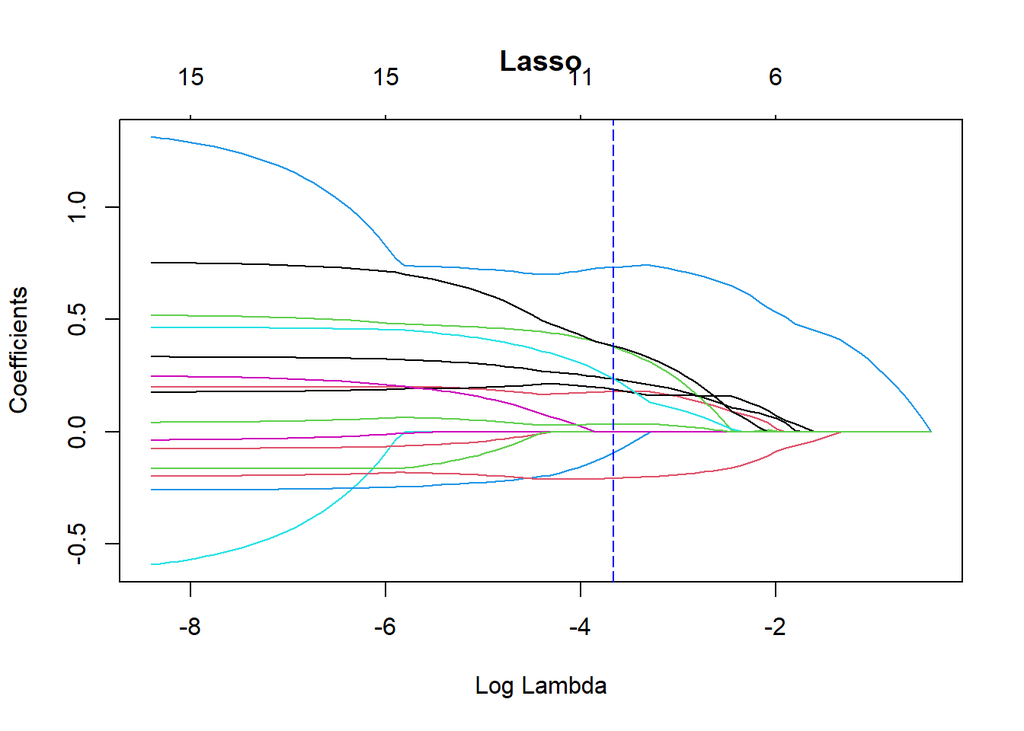

```r
plot(lasso, xvar='lambda', main="Lasso")
abline(v=log(best.lambda), col="blue", lty=5.5 )
```

Choosing the coefficients based on the lambda chosen

```r
#choosing coefficients
coef(cv.lasso, s = "lambda.min")
```

```
## 16 x 1 sparse Matrix of class "dgCMatrix"
##                         1
## (Intercept) -3.139861e-16
## M            2.361438e-01
## So           1.785041e-01
## Ed           3.787988e-01
## Po1          7.328666e-01
## Po2          .
## LF           .
## M.F          1.904635e-01
## Pop          .
## NW           .
## U1          -9.300471e-02
## U2           2.369465e-01
## Wealth       .
## Ineq         3.833617e-01
## Prob        -2.065999e-01
## Time         3.417036e-02
```

```r
select.ind = which(coef(cv.lasso, s = "lambda.min") != 0)
select.ind = select.ind[-1]-1 # remove Intercept
important <- colnames(train[select.ind])
important# which one is important
```

```
##  [1] "M"    "So"   "Ed"   "Po1"  "M.F"  "U1"   "U2"   "Ineq" "Prob" "Time"
```

```r
#Regression model
lasso.reg <- lm(Crime~., data = train[,c(important,"Crime")])
summary(lasso.reg)
```

```
##
## Call:
## lm.default(formula = Crime ~ ., data = train[, c(important, "Crime")])
##
## Residuals:
##     Min      1Q  Median      3Q     Max
## -376.11  -95.74   15.06  122.03  526.81
##
## Coefficients:
##              Estimate Std. Error t value Pr(>|t|)
## (Intercept) -7382.332   1534.545  -4.811 4.65e-05 ***
## M              88.500     40.827   2.168  0.03884 *
## So            143.343    132.641   1.081  0.28906
## Ed            193.504     59.391   3.258  0.00294 **
## Po1            90.907     19.450   4.674 6.76e-05 ***
## M.F            32.222     16.919   1.904  0.06717 .
## U1          -6809.787   4489.095  -1.517  0.14049
## U2            239.632     99.391   2.411  0.02272 *
## Ineq           50.769     18.820   2.698  0.01170 *
## Prob        -3720.703   2103.563  -1.769  0.08783 .
## Time            1.696      7.142   0.237  0.81406
## ---
## Signif. codes:  0 '***' 0.001 '**' 0.01 '*' 0.05 '.' 0.1 ' ' 1
##
## Residual standard error: 206.7 on 28 degrees of freedom
## Multiple R-squared:  0.804,  Adjusted R-squared:  0.734
## F-statistic: 11.49 on 10 and 28 DF,  p-value: 1.683e-07
```

Using test data

```r
res.lasso <- test %>%
  add_predictions(.,lasso.reg) %>%
  select('observations' = Crime, pred) %>%
  as.data.frame()
```

Regression results on test data

```r
Lasso.regression <- postResample(obs = res.lasso$observations, pred = res.lasso$pred)
Lasso.regression
```

```
##        RMSE    Rsquared         MAE
## 215.4929042   0.5093659 174.1936776
```

### 3. Elastic net

```r
#divide data
set.seed(101)
train.index <- createDataPartition(crime$Crime , p = 0.8 ,times = 1, list = F)
train <- crime[train.index,]
test <- crime[-train.index,]
```

```r
#Finding suitable aplpha
a <- seq(0.05, 0.95, 0.05)
search <- foreach(i = a, .combine = rbind) %dopar% {
cv.elastic <- cv.glmnet(x = scale(as.matrix(train[,-16])),
                  y =scale(as.matrix(train[,16]))  ,
                  family = "gaussian" ,
                  nfold = 10,
                  type.measure = "deviance",
                  paralle = TRUE,
                  alpha = i)
  data.frame(cvm = cv.elastic$cvm[cv.elastic$lambda == cv.elastic$lambda.1se],
             lambda.1se = cv.elastic$lambda.1se,
             alpha = i)
}
search
```

```
##          cvm lambda.1se alpha
## 1  0.5587357 0.68086028  0.05
## 2  0.5808445 0.37362166  0.10
## 3  0.5676798 0.27336621  0.15
## 4  0.5441202 0.20502465  0.20
## 5  0.6236860 0.19756234  0.25
## 6  0.5512257 0.23885760  0.30
## 7  0.5344820 0.11715695  0.35
## 8  0.6009797 0.12347646  0.40
## 9  0.4988893 0.10975685  0.45
## 10 0.5523747 0.09000572  0.50
## 11 0.5616747 0.09855656  0.55
## 12 0.5203781 0.09034351  0.60
## 13 0.5306673 0.09152482  0.65
## 14 0.5865062 0.09327349  0.70
## 15 0.5881139 0.08705526  0.75
## 16 0.7048490 0.08957160  0.80
## 17 0.6121278 0.10154288  0.85
## 18 0.5221102 0.07254605  0.90
## 19 0.4977953 0.06872784  0.95
```

```r
cv <- search[search$cvm == min(search$cvm), ]
cv
```

```
##          cvm lambda.1se alpha
## 19 0.4977953 0.06872784  0.95
```

```r
#modeling
elastic <- glmnet(x = scale(as.matrix(train[,-16])),
                y =scale(as.matrix(train[,16]))  ,
                family = "gaussian" ,
                alpha = cv$alpha,
                lambda = cv$lambda.1se)
```

```r
#choosing coefficients
coef(elastic, s = "lambda.min")
```

```
## 16 x 1 sparse Matrix of class "dgCMatrix"
##                         1
## (Intercept) -1.342940e-16
## M            1.515020e-01
## So           1.299846e-01
## Ed           1.351864e-01
## Po1          6.842464e-01
## Po2          .
## LF           .
## M.F          1.610136e-01
## Pop          .
## NW           .
## U1           .
## U2           6.369060e-02
## Wealth       .
## Ineq         1.878501e-01
## Prob        -1.768478e-01
## Time         1.715607e-02
```

```r
select.ind2 = which(coef(elastic, s = "lambda.min") != 0)
select.ind2 = select.ind[-1]-1 # remove Intercept
important2 <- colnames(train[select.ind2])
important2
```

```
## [1] "M"      "So"     "Ed"     "LF"     "NW"     "U1"     "Wealth" "Ineq"
## [9] "Prob"
```

```r
#Regression model
elastic.reg <- lm(Crime~., data = train[,c(important,"Crime")])
```

```r
summary(elastic.reg)
```

```
##
## Call:
## lm.default(formula = Crime ~ ., data = train[, c(important, "Crime")])
##
## Residuals:
##     Min      1Q  Median      3Q     Max
## -376.11  -95.74   15.06  122.03  526.81
##
## Coefficients:
##              Estimate Std. Error t value Pr(>|t|)
## (Intercept) -7382.332   1534.545  -4.811 4.65e-05 ***
## M              88.500     40.827   2.168  0.03884 *
## So            143.343    132.641   1.081  0.28906
## Ed            193.504     59.391   3.258  0.00294 **
## Po1            90.907     19.450   4.674 6.76e-05 ***
## M.F            32.222     16.919   1.904  0.06717 .
## U1          -6809.787   4489.095  -1.517  0.14049
## U2            239.632     99.391   2.411  0.02272 *
## Ineq           50.769     18.820   2.698  0.01170 *
## Prob        -3720.703   2103.563  -1.769  0.08783 .
## Time            1.696      7.142   0.237  0.81406
## ---
## Signif. codes:  0 '***' 0.001 '**' 0.01 '*' 0.05 '.' 0.1 ' ' 1
##
## Residual standard error: 206.7 on 28 degrees of freedom
## Multiple R-squared:  0.804,  Adjusted R-squared:  0.734
## F-statistic: 11.49 on 10 and 28 DF,  p-value: 1.683e-07
```

```r
res.elastic <- test %>%
  add_predictions(.,elastic.reg) %>%
  select('observations' = Crime, pred) %>%
  as.data.frame()
```

```r
Elastic.regression <- postResample(obs = res.lasso$observations, pred = res.lasso$pred)
Elastic.regression
```

```
##        RMSE    Rsquared         MAE
## 215.4929042   0.5093659 174.1936776
```

## Question 12.1

### Describe a situation or problem from your job, everyday life, current events, etc., for which a design of experiments approach would be appropriate.

### Answer:

One design of experiments I would implement is that of target marketing for followers of a facebook Fanpage. By using factoral design, we could target potential followers more effectively.

## Question 12.2

### To determine the value of 10 different yes/no features to the market value of a house (large yard, solar roof, etc.), a real estate agent plans to survey 50 potential buyers, showing a fictitious house with different combinations of features.

```r
FrF2(16,nfactors = 10,
     factor.names =  c("Large yard" , "solar roof" , "double restrooms" , "Garage" , "pool" ,"lawn",
                       "security system" , "Smart house system" ,"Elevator","Walk-in closet") )
```

```
##    Large.yard solar.roof double.restrooms Garage pool lawn security.system
## 1           1         -1               -1     -1   -1   -1               1
## 2          -1          1                1     -1   -1   -1               1
## 3          -1         -1                1      1    1   -1              -1
## 4           1         -1                1     -1   -1    1              -1
## 5          -1          1               -1      1   -1    1              -1
## 6          -1         -1                1     -1    1   -1              -1
## 7          -1         -1               -1     -1    1    1               1
## 8          -1         -1               -1      1    1    1               1
## 9           1         -1                1      1   -1    1              -1
## 10          1          1                1      1    1    1               1
## 11          1          1                1     -1    1    1               1
## 12          1          1               -1     -1    1   -1              -1
## 13          1         -1               -1      1   -1   -1               1
## 14         -1          1               -1     -1   -1    1              -1
```

[output cut: 20 more lines]

## Question 13.1

### For each of the following distributions, give an example of data that you would expect to follow this distribution (besides the examples already discussed in class).

### a. Binomial

The chances of strucking the grand prize of a lottery.

### b. Geometric

How many times does an average fielder successfully make a catch befor making an error.

### c. Poisson

How many people are just late for a class, just late defined as within 5 minutes after class starts.

### d. Exponential

How long does it take between students who are late for class.

### e. Weibull

How long does it take for a computer’s battery to wear out if continuously charged.